# Brain Tumor Classification Using Deep Learning

**Course**: Computer Vision AAI-521  
**Author**: Balaji Rao  
**Institution**: University of San Diego

## Project Overview

This notebook implements a deep learning solution for classifying brain tumors from MRI images using Transfer Learning with VGG16. The model classifies images into four categories:

- Glioma Tumor
- Meningioma Tumor
- No Tumor
- Pituitary Tumor

**Dataset**: [Brain Tumor Classification (MRI) - Kaggle](https://www.kaggle.com/datasets/sartajbhuvaji/brain-tumor-classification-mri)

1. Environment Setup
2. Data Loading and Exploration
3. Data Preprocessing and Augmentation
4. Model Architecture
5. Model Training
6. Model Evaluation
7. Results Visualization
8. Conclusions

## 1. Environment Setup

```python
import os
print(os.getcwd())
print(os.listdir("."))
```

```
/content
['.config', 'Testing', 'archive.zip', 'Training', 'sample_data']
```

```python
# Import required libraries
import os
import numpy as np
import pandas as pd
import matplotlib.pyplot as plt
import seaborn as sns
import cv2
from pathlib import Path
import random
from tqdm import tqdm

# Deep Learning Libraries
import tensorflow as tf
from tensorflow import keras
from tensorflow.keras.models import Sequential, Model
from tensorflow.keras.layers import Dense, Dropout, Flatten, GlobalAveragePooling2D
from tensorflow.keras.preprocessing.image import ImageDataGenerator, load_img, img_to_array
from tensorflow.keras.applications import VGG16
from tensorflow.keras.optimizers import Adam
from tensorflow.keras.callbacks import EarlyStopping, ModelCheckpoint, ReduceLROnPlateau

# Scikit-learn for evaluation
from sklearn.metrics import classification_report, confusion_matrix, roc_curve, auc
from sklearn.preprocessing import label_binarize

# Display settings
plt.style.use('seaborn-v0_8-darkgrid')
sns.set_palette("husl")
%matplotlib inline

# Set random seeds for reproducibility
SEED = 42
np.random.seed(SEED)
random.seed(SEED)
tf.random.set_seed(SEED)

# Suppress warnings
import warnings
warnings.filterwarnings('ignore')

print("TensorFlow Version:", tf.__version__)
print("Keras Version:", keras.__version__)
print("GPU Available:", tf.config.list_physical_devices('GPU'))
```

```
TensorFlow Version: 2.19.0
Keras Version: 3.10.0
GPU Available: [PhysicalDevice(name='/physical_device:GPU:0', device_type='GPU')]
```

## 2. Data Loading and Exploration

### 2.1 Define Paths and Constants

```python
!unzip -q archive.zip -d /content
```

```python
BASE_DIR = Path('.')
DATASET_DIR = BASE_DIR / 'dataset'
print('Running locally')

TRAIN_DIR = Path("Training")
TEST_DIR = Path("Testing")

# Model and results directories
MODEL_DIR = Path('models')
RESULTS_DIR = Path('results')
MODEL_DIR.mkdir(exist_ok=True)
RESULTS_DIR.mkdir(exist_ok=True)

# Image parameters
IMG_SIZE = 224  # VGG16 input size
IMG_SHAPE = (IMG_SIZE, IMG_SIZE, 3)
BATCH_SIZE = 32

# Class names
CLASS_NAMES = ['glioma_tumor', 'meningioma_tumor', 'no_tumor', 'pituitary_tumor']
NUM_CLASSES = len(CLASS_NAMES)

print(f"Dataset Directory: {DATASET_DIR}")
print(f"Training Directory: {TRAIN_DIR}")
print(f"Testing Directory: {TEST_DIR}")
print(f"Number of Classes: {NUM_CLASSES}")
print(f"Classes: {CLASS_NAMES}")
```

```
Running locally
Dataset Directory: dataset
Training Directory: Training
Testing Directory: Testing
Number of Classes: 4
Classes: ['glioma_tumor', 'meningioma_tumor', 'no_tumor', 'pituitary_tumor']
```

### 2.2 Dataset Statistics

```python
# Count images per class
def count_images(directory):
    """Count number of images in each class folder."""
    counts = {}
    for class_name in CLASS_NAMES:
        class_path = directory / class_name

        if class_path.exists():
            counts[class_name] = len(list(class_path.glob('*.jpg')))
        else:
            counts[class_name] = 0
    return counts

# Get counts
train_counts = count_images(TRAIN_DIR)
test_counts = count_images(TEST_DIR)

# Create DataFrame for visualization
df_stats = pd.DataFrame({
    'Class': CLASS_NAMES,
    'Training': [train_counts[c] for c in CLASS_NAMES],
    'Testing': [test_counts[c] for c in CLASS_NAMES]
})
df_stats['Total'] = df_stats['Training'] + df_stats['Testing']

print("\nDataset Distribution:")
print(df_stats)
print(f"\nTotal Training Images: {df_stats['Training'].sum()}")
print(f"Total Testing Images: {df_stats['Testing'].sum()}")
print(f"Total Images: {df_stats['Total'].sum()}")
```

```
Dataset Distribution:
              Class  Training  Testing  Total
0      glioma_tumor       826      100    926
1  meningioma_tumor       822      115    937
2          no_tumor       395      105    500
3   pituitary_tumor       827       74    901

Total Training Images: 2870
Total Testing Images: 394
Total Images: 3264
```

### 2.3 Visualize Dataset Distribution

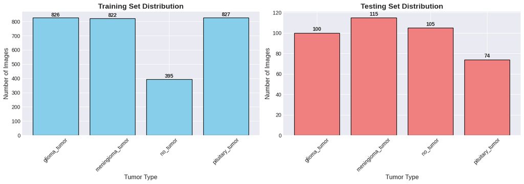

```python
# Plot dataset distribution
fig, axes = plt.subplots(1, 2, figsize=(14, 5))

# Training set distribution
axes[0].bar(CLASS_NAMES, [train_counts[c] for c in CLASS_NAMES], color='skyblue', edgecolor='black')
axes[0].set_title('Training Set Distribution', fontsize=14, fontweight='bold')
axes[0].set_xlabel('Tumor Type', fontsize=12)
axes[0].set_ylabel('Number of Images', fontsize=12)
axes[0].tick_params(axis='x', rotation=45)
for i, v in enumerate([train_counts[c] for c in CLASS_NAMES]):
    axes[0].text(i, v + 10, str(v), ha='center', fontweight='bold')

# Testing set distribution
axes[1].bar(CLASS_NAMES, [test_counts[c] for c in CLASS_NAMES], color='lightcoral', edgecolor='black')
axes[1].set_title('Testing Set Distribution', fontsize=14, fontweight='bold')
axes[1].set_xlabel('Tumor Type', fontsize=12)
axes[1].set_ylabel('Number of Images', fontsize=12)
axes[1].tick_params(axis='x', rotation=45)
for i, v in enumerate([test_counts[c] for c in CLASS_NAMES]):
    axes[1].text(i, v + 2, str(v), ha='center', fontweight='bold')

plt.tight_layout()
plt.savefig(RESULTS_DIR / 'dataset_distribution.png', dpi=300, bbox_inches='tight')
plt.show()
```

### 2.4 Visualize Sample Images

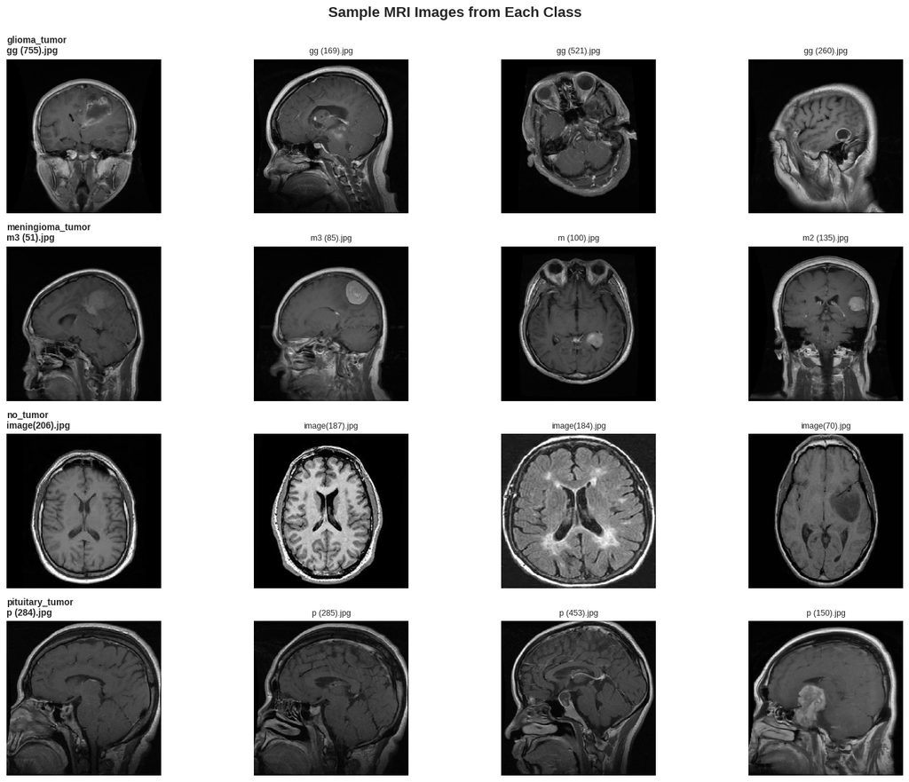

```python
# Display sample images from each class
def display_sample_images(directory, classes, samples_per_class=4):
    """Display sample images from each class."""
    fig, axes = plt.subplots(len(classes), samples_per_class, figsize=(16, 12))

    for i, class_name in enumerate(classes):
        class_path = directory / class_name
        image_files = list(class_path.glob('*.jpg'))[:samples_per_class]

        for j, img_path in enumerate(image_files):
            img = load_img(img_path, target_size=(IMG_SIZE, IMG_SIZE))
            img_array = img_to_array(img) / 255.0

            axes[i, j].imshow(img_array)
            axes[i, j].axis('off')
            if j == 0:
                axes[i, j].set_title(f'{class_name}\n{img_path.name}',
                                     fontsize=10, fontweight='bold', loc='left')
            else:
                axes[i, j].set_title(img_path.name, fontsize=9)

    plt.suptitle('Sample MRI Images from Each Class', fontsize=16, fontweight='bold', y=0.995)
    plt.tight_layout()
    plt.savefig(RESULTS_DIR / 'sample_images.png', dpi=300, bbox_inches='tight')
    plt.show()

display_sample_images(TRAIN_DIR, CLASS_NAMES, samples_per_class=4)
```

## 3. Data Preprocessing and Augmentation

### 3.1 Create Data Generators

We use ImageDataGenerator for:

- Normalization (rescaling pixel values to [0, 1])
- Data augmentation to increase training data diversity
- Automatic batching and shuffling

```python
# Training data generator with augmentation
train_datagen = ImageDataGenerator(
    rescale=1./255,                  # Normalize pixel values to [0, 1]
    rotation_range=15,               # Random rotation ±15 degrees
    width_shift_range=0.05,          # Horizontal shift 5%
    height_shift_range=0.05,         # Vertical shift 5%
    shear_range=0.05,                # Shear transformation
    zoom_range=0.05,                 # Random zoom
    brightness_range=[0.8, 1.2],     # Brightness variation
    horizontal_flip=True,            # Random horizontal flip
    vertical_flip=True,              # Random vertical flip
    fill_mode='nearest',             # Fill strategy for new pixels
    validation_split=0.2             # 20% for validation
)

# Testing data generator (only rescaling, no augmentation)
test_datagen = ImageDataGenerator(
    rescale=1./255
)

# Create training generator
train_generator = train_datagen.flow_from_directory(
    TRAIN_DIR,
    target_size=(IMG_SIZE, IMG_SIZE),
    batch_size=BATCH_SIZE,
    class_mode='categorical',
    subset='training',
    shuffle=True,
    seed=SEED
)

# Create validation generator
val_generator = train_datagen.flow_from_directory(
    TRAIN_DIR,
    target_size=(IMG_SIZE, IMG_SIZE),
    batch_size=BATCH_SIZE,
    class_mode='categorical',
    subset='validation',
    shuffle=True,
    seed=SEED
)

# Create test generator
test_generator = test_datagen.flow_from_directory(
    TEST_DIR,
    target_size=(IMG_SIZE, IMG_SIZE),
    batch_size=BATCH_SIZE,
    class_mode='categorical',
    shuffle=False  # Important: don't shuffle test data
)

print(f"Training samples: {train_generator.samples}")
print(f"Validation samples: {val_generator.samples}")
print(f"Testing samples: {test_generator.samples}")
print(f"\nClass indices: {train_generator.class_indices}")
```

```
Found 2297 images belonging to 4 classes.
Found 573 images belonging to 4 classes.
Found 394 images belonging to 4 classes.
Training samples: 2297
Validation samples: 573
Testing samples: 394

Class indices: {'glioma_tumor': 0, 'meningioma_tumor': 1, 'no_tumor': 2, 'pituitary_tumor': 3}
```

### 3.2 Visualize Augmented Images

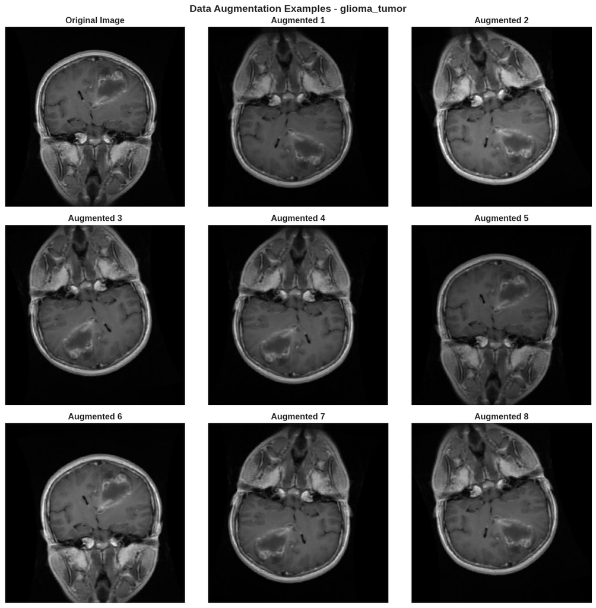

```python
# Show augmented versions of a sample image
def visualize_augmentation(directory, class_name, num_augmentations=9):
    """Display original image and augmented versions."""
    # Get a sample image
    class_path = directory / class_name
    img_path = list(class_path.glob('*.jpg'))[0]
    img = load_img(img_path, target_size=(IMG_SIZE, IMG_SIZE))
    img_array = img_to_array(img)
    img_array = img_array.reshape((1,) + img_array.shape)

    # Create augmentation generator
    aug_gen = ImageDataGenerator(
        rotation_range=15,
        width_shift_range=0.05,
        height_shift_range=0.05,
        brightness_range=[0.8, 1.2],
        horizontal_flip=True,
        vertical_flip=True
    )

    # Generate augmented images
    fig, axes = plt.subplots(3, 3, figsize=(12, 12))
    axes = axes.flatten()

    # Show original
    axes[0].imshow(img)
    axes[0].set_title('Original Image', fontweight='bold')
    axes[0].axis('off')

    # Show augmented versions
    i = 1
    for batch in aug_gen.flow(img_array, batch_size=1):
        axes[i].imshow(batch[0].astype('uint8'))
        axes[i].set_title(f'Augmented {i}', fontweight='bold')
        axes[i].axis('off')
        i += 1
        if i >= num_augmentations:
            break

    plt.suptitle(f'Data Augmentation Examples - {class_name}', fontsize=14, fontweight='bold')
    plt.tight_layout()
    plt.savefig(RESULTS_DIR / 'augmentation_examples.png', dpi=300, bbox_inches='tight')
    plt.show()

visualize_augmentation(TRAIN_DIR, 'glioma_tumor')
```

## 4. Model Architecture

### 4.1 Build VGG16 Transfer Learning Model

We use VGG16 pre-trained on ImageNet as the base model and add a custom classification head for our 4-class problem.

```python
def create_vgg16_model(num_classes=4, fine_tune=True, learning_rate=0.0001):
    """
    Create VGG16 transfer learning model.

    Args:
        num_classes: Number of output classes
        fine_tune: If True, unfreeze all layers. If False, freeze base layers.
        learning_rate: Learning rate for optimizer

    Returns:
        Compiled Keras model
    """
    # Load VGG16 base model (without top classification layers)
    base_model = VGG16(
        weights='imagenet',
        include_top=False,
        input_shape=IMG_SHAPE
    )

    # Freeze/unfreeze base model layers
    if not fine_tune:
        for layer in base_model.layers:
            layer.trainable = False
        print("Base model layers frozen (feature extraction mode)")
    else:
        for layer in base_model.layers:
            layer.trainable = True
        print("Base model layers unfrozen (fine-tuning mode)")

    # Build model using Sequential API
    model = Sequential([
        base_model,
        Flatten(),
        Dense(num_classes, activation='softmax', name='output')
    ], name='VGG16_Transfer_Learning')

    # Compile model
    model.compile(
        optimizer=Adam(learning_rate=learning_rate),
        loss='categorical_crossentropy',
        metrics=['accuracy']
    )

    return model

# Create model
model = create_vgg16_model(num_classes=NUM_CLASSES, fine_tune=True, learning_rate=0.0001)

# Display model summary
print("\nModel Summary:")
model.summary()

# Count parameters
total_params = model.count_params()
trainable_params = sum([tf.size(w).numpy() for w in model.trainable_weights])
non_trainable_params = total_params - trainable_params

print(f"\nTotal parameters: {total_params:,}")
print(f"Trainable parameters: {trainable_params:,}")
print(f"Non-trainable parameters: {non_trainable_params:,}")
```

```
Downloading data from https://storage.googleapis.com/tensorflow/keras-applications/vgg16/vgg16_weights_tf_dim_ordering_tf_kernels_notop.h5
58889256/58889256 ━━━━━━━━━━━━━━━━━━━━ 0s 0us/step
Base model layers unfrozen (fine-tuning mode)

Model Summary:
```

```
Model: "VGG16_Transfer_Learning"
```

```
┏━━━━━━━━━━━━━━━━━━━━━━━━━━━━━━━━━┳━━━━━━━━━━━━━━━━━━━━━━━━┳━━━━━━━━━━━━━━━┓
┃ Layer (type)                    ┃ Output Shape           ┃       Param # ┃
┡━━━━━━━━━━━━━━━━━━━━━━━━━━━━━━━━━╇━━━━━━━━━━━━━━━━━━━━━━━━╇━━━━━━━━━━━━━━━┩
│ vgg16 (Functional)              │ (None, 7, 7, 512)      │    14,714,688 │
├─────────────────────────────────┼────────────────────────┼───────────────┤
│ flatten (Flatten)               │ (None, 25088)          │             0 │
├─────────────────────────────────┼────────────────────────┼───────────────┤
│ output (Dense)                  │ (None, 4)              │       100,356 │
└─────────────────────────────────┴────────────────────────┴───────────────┘
```

```
 Total params: 14,815,044 (56.51 MB)
```

```
 Trainable params: 14,815,044 (56.51 MB)
```

```
 Non-trainable params: 0 (0.00 B)
```

```
Total parameters: 14,815,044
Trainable parameters: 14,815,044
Non-trainable parameters: 0
```

### 4.2 Alternative Model with Dropout

Optional: Create a model with additional dropout for regularization

```python
def create_vgg16_with_dropout(num_classes=4, dropout_rate=0.5, learning_rate=0.0001):
    """
    Create VGG16 model with additional dropout layer.
    """
    base_model = VGG16(
        weights='imagenet',
        include_top=False,
        input_shape=IMG_SHAPE
    )

    # Unfreeze all layers
    for layer in base_model.layers:
        layer.trainable = True

    # Build model with dropout
    model = Sequential([
        base_model,
        Flatten(),
        Dropout(dropout_rate),
        Dense(num_classes, activation='softmax', name='output')
    ], name='VGG16_With_Dropout')

    model.compile(
        optimizer=Adam(learning_rate=learning_rate),
        loss='categorical_crossentropy',
        metrics=['accuracy']
    )

    return model

# Uncomment to use dropout model instead
model = create_vgg16_with_dropout(num_classes=NUM_CLASSES, dropout_rate=0.5)
```

## 5. Model Training

### 5.1 Setup Training Callbacks

```python
# Define callbacks
callbacks = [
    # Early stopping: stop training if validation loss doesn't improve
    EarlyStopping(
        monitor='val_loss',
        patience=5,
        restore_best_weights=True,
        verbose=1
    ),

    # Model checkpoint: save best model
    ModelCheckpoint(
        filepath=str(MODEL_DIR / 'best_model.h5'),
        monitor='val_accuracy',
        save_best_only=True,
        verbose=1
    ),

    # Reduce learning rate when validation loss plateaus
    ReduceLROnPlateau(
        monitor='val_loss',
        factor=0.5,
        patience=3,
        min_lr=1e-7,
        verbose=1
    )
]

print("Callbacks configured:")
for callback in callbacks:
    print(f"  - {callback.__class__.__name__}")
```

```
Callbacks configured:
  - EarlyStopping
  - ModelCheckpoint
  - ReduceLROnPlateau
```

### 5.2 Train the Model

```python
# Training parameters
EPOCHS = 30

# Calculate steps per epoch
steps_per_epoch = train_generator.samples // BATCH_SIZE
validation_steps = val_generator.samples // BATCH_SIZE

print(f"Training configuration:")
print(f"  Epochs: {EPOCHS}")
print(f"  Batch size: {BATCH_SIZE}")
print(f"  Steps per epoch: {steps_per_epoch}")
print(f"  Validation steps: {validation_steps}")
print(f"\nStarting training...\n")

# Train model
history = model.fit(
    train_generator,
    steps_per_epoch=steps_per_epoch,
    epochs=EPOCHS,
    validation_data=val_generator,
    validation_steps=validation_steps,
    callbacks=callbacks,
    verbose=1
)

print("\nTraining completed!")
```

```
Training configuration:
  Epochs: 30
  Batch size: 32
  Steps per epoch: 71
  Validation steps: 17

Starting training...

71/71 ━━━━━━━━━━━━━━━━━━━━ 0s 1s/step - accuracy: 0.4453 - loss: 1.2095
Epoch 1: val_accuracy improved from -inf to 0.45221, saving model to models/best_model.h5
```

```
WARNING:absl:You are saving your model as an HDF5 file via `model.save()` or `keras.saving.save_model(model)`. This file format is considered legacy. We recommend using instead the native Keras format, e.g. `model.save('my_model.keras')` or `keras.saving.save_model(model, 'my_model.keras')`.
```

```
71/71 ━━━━━━━━━━━━━━━━━━━━ 139s 1s/step - accuracy: 0.4466 - loss: 1.2076 - val_accuracy: 0.4522 - val_loss: 1.1221 - learning_rate: 1.0000e-04
 1/71 ━━━━━━━━━━━━━━━━━━━━ 32s 462ms/step - accuracy: 0.7500 - loss: 0.7157
Epoch 2: val_accuracy did not improve from 0.45221
71/71 ━━━━━━━━━━━━━━━━━━━━ 9s 122ms/step - accuracy: 0.7500 - loss: 0.7157 - val_accuracy: 0.3805 - val_loss: 1.3628 - learning_rate: 1.0000e-04
71/71 ━━━━━━━━━━━━━━━━━━━━ 0s 594ms/step - accuracy: 0.7003 - loss: 0.7417
Epoch 3: val_accuracy improved from 0.45221 to 0.71691, saving model to models/best_model.h5
```

```
WARNING:absl:You are saving your model as an HDF5 file via `model.save()` or `keras.saving.save_model(model)`. This file format is considered legacy. We recommend using instead the native Keras format, e.g. `model.save('my_model.keras')` or `keras.saving.save_model(model, 'my_model.keras')`.
```

```
71/71 ━━━━━━━━━━━━━━━━━━━━ 52s 725ms/step - accuracy: 0.7008 - loss: 0.7407 - val_accuracy: 0.7169 - val_loss: 0.7648 - learning_rate: 1.0000e-04
 1/71 ━━━━━━━━━━━━━━━━━━━━ 31s 456ms/step - accuracy: 0.6250 - loss: 0.8047
Epoch 4: val_accuracy improved from 0.71691 to 0.74632, saving model to models/best_model.h5
```

```
WARNING:absl:You are saving your model as an HDF5 file via `model.save()` or `keras.saving.save_model(model)`. This file format is considered legacy. We recommend using instead the native Keras format, e.g. `model.save('my_model.keras')` or `keras.saving.save_model(model, 'my_model.keras')`.
```

```
71/71 ━━━━━━━━━━━━━━━━━━━━ 9s 127ms/step - accuracy: 0.6250 - loss: 0.8047 - val_accuracy: 0.7463 - val_loss: 0.6562 - learning_rate: 1.0000e-04
71/71 ━━━━━━━━━━━━━━━━━━━━ 0s 593ms/step - accuracy: 0.7943 - loss: 0.5362
Epoch 5: val_accuracy improved from 0.74632 to 0.81250, saving model to models/best_model.h5
```

```
WARNING:absl:You are saving your model as an HDF5 file via `model.save()` or `keras.saving.save_model(model)`. This file format is considered legacy. We recommend using instead the native Keras format, e.g. `model.save('my_model.keras')` or `keras.saving.save_model(model, 'my_model.keras')`.
```

```
71/71 ━━━━━━━━━━━━━━━━━━━━ 81s 1s/step - accuracy: 0.7946 - loss: 0.5357 - val_accuracy: 0.8125 - val_loss: 0.5053 - learning_rate: 1.0000e-04
 1/71 ━━━━━━━━━━━━━━━━━━━━ 31s 452ms/step - accuracy: 0.9062 - loss: 0.2255
Epoch 6: val_accuracy did not improve from 0.81250
71/71 ━━━━━━━━━━━━━━━━━━━━ 9s 118ms/step - accuracy: 0.9062 - loss: 0.2255 - val_accuracy: 0.8125 - val_loss: 0.5319 - learning_rate: 1.0000e-04
71/71 ━━━━━━━━━━━━━━━━━━━━ 0s 598ms/step - accuracy: 0.8796 - loss: 0.3406
Epoch 7: val_accuracy improved from 0.81250 to 0.84375, saving model to models/best_model.h5
```

```
WARNING:absl:You are saving your model as an HDF5 file via `model.save()` or `keras.saving.save_model(model)`. This file format is considered legacy. We recommend using instead the native Keras format, e.g. `model.save('my_model.keras')` or `keras.saving.save_model(model, 'my_model.keras')`.
```

```
71/71 ━━━━━━━━━━━━━━━━━━━━ 104s 728ms/step - accuracy: 0.8795 - loss: 0.3408 - val_accuracy: 0.8438 - val_loss: 0.4780 - learning_rate: 1.0000e-04
 1/71 ━━━━━━━━━━━━━━━━━━━━ 31s 453ms/step - accuracy: 0.8750 - loss: 0.2920
Epoch 8: val_accuracy did not improve from 0.84375
71/71 ━━━━━━━━━━━━━━━━━━━━ 9s 123ms/step - accuracy: 0.8750 - loss: 0.2920 - val_accuracy: 0.8438 - val_loss: 0.4325 - learning_rate: 1.0000e-04
71/71 ━━━━━━━━━━━━━━━━━━━━ 0s 591ms/step - accuracy: 0.8935 - loss: 0.3060
Epoch 9: val_accuracy improved from 0.84375 to 0.86949, saving model to models/best_model.h5
```

```
WARNING:absl:You are saving your model as an HDF5 file via `model.save()` or `keras.saving.save_model(model)`. This file format is considered legacy. We recommend using instead the native Keras format, e.g. `model.save('my_model.keras')` or `keras.saving.save_model(model, 'my_model.keras')`.
```

```
71/71 ━━━━━━━━━━━━━━━━━━━━ 82s 1s/step - accuracy: 0.8936 - loss: 0.3056 - val_accuracy: 0.8695 - val_loss: 0.3938 - learning_rate: 1.0000e-04
 1/71 ━━━━━━━━━━━━━━━━━━━━ 27s 390ms/step - accuracy: 0.9200 - loss: 0.1960
Epoch 10: val_accuracy did not improve from 0.86949
71/71 ━━━━━━━━━━━━━━━━━━━━ 9s 121ms/step - accuracy: 0.9200 - loss: 0.1960 - val_accuracy: 0.8603 - val_loss: 0.4042 - learning_rate: 1.0000e-04
71/71 ━━━━━━━━━━━━━━━━━━━━ 0s 601ms/step - accuracy: 0.9298 - loss: 0.2176
Epoch 11: val_accuracy did not improve from 0.86949
71/71 ━━━━━━━━━━━━━━━━━━━━ 51s 716ms/step - accuracy: 0.9297 - loss: 0.2177 - val_accuracy: 0.8640 - val_loss: 0.3808 - learning_rate: 1.0000e-04
 1/71 ━━━━━━━━━━━━━━━━━━━━ 31s 452ms/step - accuracy: 0.8750 - loss: 0.3370
Epoch 12: val_accuracy did not improve from 0.86949
71/71 ━━━━━━━━━━━━━━━━━━━━ 9s 120ms/step - accuracy: 0.8750 - loss: 0.3370 - val_accuracy: 0.8585 - val_loss: 0.4369 - learning_rate: 1.0000e-04
71/71 ━━━━━━━━━━━━━━━━━━━━ 0s 604ms/step - accuracy: 0.9302 - loss: 0.2157
Epoch 13: val_accuracy did not improve from 0.86949
71/71 ━━━━━━━━━━━━━━━━━━━━ 52s 727ms/step - accuracy: 0.9302 - loss: 0.2158 - val_accuracy: 0.8676 - val_loss: 0.3894 - learning_rate: 1.0000e-04
 1/71 ━━━━━━━━━━━━━━━━━━━━ 31s 454ms/step - accuracy: 0.9688 - loss: 0.1037
Epoch 14: val_accuracy did not improve from 0.86949

Epoch 14: ReduceLROnPlateau reducing learning rate to 4.999999873689376e-05.
71/71 ━━━━━━━━━━━━━━━━━━━━ 9s 120ms/step - accuracy: 0.9688 - loss: 0.1037 - val_accuracy: 0.8529 - val_loss: 0.4130 - learning_rate: 1.0000e-04
71/71 ━━━━━━━━━━━━━━━━━━━━ 0s 604ms/step - accuracy: 0.9341 - loss: 0.1897
Epoch 15: val_accuracy improved from 0.86949 to 0.88235, saving model to models/best_model.h5
```

```
WARNING:absl:You are saving your model as an HDF5 file via `model.save()` or `keras.saving.save_model(model)`. This file format is considered legacy. We recommend using instead the native Keras format, e.g. `model.save('my_model.keras')` or `keras.saving.save_model(model, 'my_model.keras')`.
```

```
71/71 ━━━━━━━━━━━━━━━━━━━━ 53s 735ms/step - accuracy: 0.9342 - loss: 0.1895 - val_accuracy: 0.8824 - val_loss: 0.3412 - learning_rate: 5.0000e-05
 1/71 ━━━━━━━━━━━━━━━━━━━━ 31s 453ms/step - accuracy: 0.9375 - loss: 0.2096
Epoch 16: val_accuracy did not improve from 0.88235
71/71 ━━━━━━━━━━━━━━━━━━━━ 9s 122ms/step - accuracy: 0.9375 - loss: 0.2096 - val_accuracy: 0.8805 - val_loss: 0.3433 - learning_rate: 5.0000e-05
71/71 ━━━━━━━━━━━━━━━━━━━━ 0s 594ms/step - accuracy: 0.9574 - loss: 0.1251
Epoch 17: val_accuracy improved from 0.88235 to 0.88971, saving model to models/best_model.h5
```

```
WARNING:absl:You are saving your model as an HDF5 file via `model.save()` or `keras.saving.save_model(model)`. This file format is considered legacy. We recommend using instead the native Keras format, e.g. `model.save('my_model.keras')` or `keras.saving.save_model(model, 'my_model.keras')`.
```

```
71/71 ━━━━━━━━━━━━━━━━━━━━ 52s 724ms/step - accuracy: 0.9574 - loss: 0.1251 - val_accuracy: 0.8897 - val_loss: 0.3860 - learning_rate: 5.0000e-05
 1/71 ━━━━━━━━━━━━━━━━━━━━ 31s 455ms/step - accuracy: 0.9062 - loss: 0.3267
Epoch 18: val_accuracy did not improve from 0.88971

Epoch 18: ReduceLROnPlateau reducing learning rate to 2.499999936844688e-05.
71/71 ━━━━━━━━━━━━━━━━━━━━ 9s 123ms/step - accuracy: 0.9062 - loss: 0.3267 - val_accuracy: 0.8805 - val_loss: 0.3657 - learning_rate: 5.0000e-05
71/71 ━━━━━━━━━━━━━━━━━━━━ 0s 601ms/step - accuracy: 0.9718 - loss: 0.0859
Epoch 19: val_accuracy improved from 0.88971 to 0.89706, saving model to models/best_model.h5
```

```
WARNING:absl:You are saving your model as an HDF5 file via `model.save()` or `keras.saving.save_model(model)`. This file format is considered legacy. We recommend using instead the native Keras format, e.g. `model.save('my_model.keras')` or `keras.saving.save_model(model, 'my_model.keras')`.
```

```
71/71 ━━━━━━━━━━━━━━━━━━━━ 52s 729ms/step - accuracy: 0.9718 - loss: 0.0859 - val_accuracy: 0.8971 - val_loss: 0.3324 - learning_rate: 2.5000e-05
 1/71 ━━━━━━━━━━━━━━━━━━━━ 31s 455ms/step - accuracy: 0.9688 - loss: 0.0712
Epoch 20: val_accuracy did not improve from 0.89706
71/71 ━━━━━━━━━━━━━━━━━━━━ 8s 111ms/step - accuracy: 0.9688 - loss: 0.0712 - val_accuracy: 0.8915 - val_loss: 0.3455 - learning_rate: 2.5000e-05
71/71 ━━━━━━━━━━━━━━━━━━━━ 0s 603ms/step - accuracy: 0.9726 - loss: 0.0883
Epoch 21: val_accuracy improved from 0.89706 to 0.89890, saving model to models/best_model.h5
```

```
WARNING:absl:You are saving your model as an HDF5 file via `model.save()` or `keras.saving.save_model(model)`. This file format is considered legacy. We recommend using instead the native Keras format, e.g. `model.save('my_model.keras')` or `keras.saving.save_model(model, 'my_model.keras')`.
```

```
71/71 ━━━━━━━━━━━━━━━━━━━━ 53s 732ms/step - accuracy: 0.9726 - loss: 0.0882 - val_accuracy: 0.8989 - val_loss: 0.2992 - learning_rate: 2.5000e-05
 1/71 ━━━━━━━━━━━━━━━━━━━━ 31s 456ms/step - accuracy: 1.0000 - loss: 0.0108
Epoch 22: val_accuracy improved from 0.89890 to 0.90809, saving model to models/best_model.h5
```

```
WARNING:absl:You are saving your model as an HDF5 file via `model.save()` or `keras.saving.save_model(model)`. This file format is considered legacy. We recommend using instead the native Keras format, e.g. `model.save('my_model.keras')` or `keras.saving.save_model(model, 'my_model.keras')`.
```

```
71/71 ━━━━━━━━━━━━━━━━━━━━ 9s 116ms/step - accuracy: 1.0000 - loss: 0.0108 - val_accuracy: 0.9081 - val_loss: 0.2865 - learning_rate: 2.5000e-05
71/71 ━━━━━━━━━━━━━━━━━━━━ 0s 599ms/step - accuracy: 0.9723 - loss: 0.0701
Epoch 23: val_accuracy did not improve from 0.90809
71/71 ━━━━━━━━━━━━━━━━━━━━ 51s 713ms/step - accuracy: 0.9723 - loss: 0.0701 - val_accuracy: 0.9026 - val_loss: 0.3118 - learning_rate: 2.5000e-05
 1/71 ━━━━━━━━━━━━━━━━━━━━ 32s 458ms/step - accuracy: 1.0000 - loss: 0.0534
Epoch 24: val_accuracy did not improve from 0.90809
71/71 ━━━━━━━━━━━━━━━━━━━━ 9s 116ms/step - accuracy: 1.0000 - loss: 0.0534 - val_accuracy: 0.8952 - val_loss: 0.2991 - learning_rate: 2.5000e-05
71/71 ━━━━━━━━━━━━━━━━━━━━ 0s 598ms/step - accuracy: 0.9848 - loss: 0.0487
Epoch 25: val_accuracy did not improve from 0.90809

Epoch 25: ReduceLROnPlateau reducing learning rate to 1.249999968422344e-05.
71/71 ━━━━━━━━━━━━━━━━━━━━ 51s 710ms/step - accuracy: 0.9848 - loss: 0.0487 - val_accuracy: 0.8934 - val_loss: 0.3577 - learning_rate: 2.5000e-05
 1/71 ━━━━━━━━━━━━━━━━━━━━ 31s 456ms/step - accuracy: 1.0000 - loss: 0.0458
Epoch 26: val_accuracy did not improve from 0.90809
71/71 ━━━━━━━━━━━━━━━━━━━━ 9s 122ms/step - accuracy: 1.0000 - loss: 0.0458 - val_accuracy: 0.8897 - val_loss: 0.3528 - learning_rate: 1.2500e-05
71/71 ━━━━━━━━━━━━━━━━━━━━ 0s 596ms/step - accuracy: 0.9832 - loss: 0.0506
Epoch 27: val_accuracy improved from 0.90809 to 0.91176, saving model to models/best_model.h5
```

```
WARNING:absl:You are saving your model as an HDF5 file via `model.save()` or `keras.saving.save_model(model)`. This file format is considered legacy. We recommend using instead the native Keras format, e.g. `model.save('my_model.keras')` or `keras.saving.save_model(model, 'my_model.keras')`.
```

```
71/71 ━━━━━━━━━━━━━━━━━━━━ 82s 1s/step - accuracy: 0.9832 - loss: 0.0506 - val_accuracy: 0.9118 - val_loss: 0.3211 - learning_rate: 1.2500e-05
Epoch 27: early stopping
Restoring model weights from the end of the best epoch: 22.

Training completed!
```

### 5.3 Save Training History

```python
# Save training history to CSV
history_df = pd.DataFrame(history.history)
history_df.to_csv(RESULTS_DIR / 'training_history.csv', index=False)
print(f"Training history saved to {RESULTS_DIR / 'training_history.csv'}")

# Display final metrics
print("\nFinal Training Metrics:")
print(f"  Training Accuracy: {history.history['accuracy'][-1]:.4f}")
print(f"  Training Loss: {history.history['loss'][-1]:.4f}")
print(f"  Validation Accuracy: {history.history['val_accuracy'][-1]:.4f}")
print(f"  Validation Loss: {history.history['val_loss'][-1]:.4f}")
```

```
Training history saved to results/training_history.csv

Final Training Metrics:
  Training Accuracy: 0.9837
  Training Loss: 0.0475
  Validation Accuracy: 0.9118
  Validation Loss: 0.3211
```

### 5.4 Plot Training History

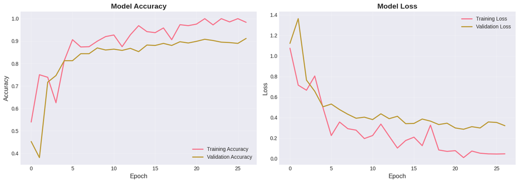

```python
# Plot training and validation metrics
def plot_training_history(history):
    """Plot training and validation accuracy/loss."""
    fig, axes = plt.subplots(1, 2, figsize=(14, 5))

    # Accuracy plot
    axes[0].plot(history.history['accuracy'], label='Training Accuracy', linewidth=2)
    axes[0].plot(history.history['val_accuracy'], label='Validation Accuracy', linewidth=2)
    axes[0].set_title('Model Accuracy', fontsize=14, fontweight='bold')
    axes[0].set_xlabel('Epoch', fontsize=12)
    axes[0].set_ylabel('Accuracy', fontsize=12)
    axes[0].legend(loc='lower right')
    axes[0].grid(True, alpha=0.3)

    # Loss plot
    axes[1].plot(history.history['loss'], label='Training Loss', linewidth=2)
    axes[1].plot(history.history['val_loss'], label='Validation Loss', linewidth=2)
    axes[1].set_title('Model Loss', fontsize=14, fontweight='bold')
    axes[1].set_xlabel('Epoch', fontsize=12)
    axes[1].set_ylabel('Loss', fontsize=12)
    axes[1].legend(loc='upper right')
    axes[1].grid(True, alpha=0.3)

    plt.tight_layout()
    plt.savefig(RESULTS_DIR / 'training_history.png', dpi=300, bbox_inches='tight')
    plt.show()

plot_training_history(history)
```

## 6. Model Evaluation

### 6.1 Evaluate on Test Set

```python
# Evaluate on test set
print("Evaluating model on test set...\n")
test_loss, test_accuracy = model.evaluate(test_generator, verbose=1)

print(f"\nTest Results:")
print(f"  Test Loss: {test_loss:.4f}")
print(f"  Test Accuracy: {test_accuracy:.4f} ({test_accuracy*100:.2f}%)")
```

```
Evaluating model on test set...

13/13 ━━━━━━━━━━━━━━━━━━━━ 7s 550ms/step - accuracy: 0.5468 - loss: 4.8208

Test Results:
  Test Loss: 2.5700
  Test Accuracy: 0.7005 (70.05%)
```

### 6.2 Generate Predictions

```python
# Generate predictions
print("Generating predictions on test set...")
test_generator.reset()
y_pred_probs = model.predict(test_generator, verbose=1)
y_pred = np.argmax(y_pred_probs, axis=1)
y_true = test_generator.classes

print(f"Predictions shape: {y_pred_probs.shape}")
print(f"Number of test samples: {len(y_true)}")
```

```
Generating predictions on test set...
13/13 ━━━━━━━━━━━━━━━━━━━━ 3s 198ms/step
Predictions shape: (394, 4)
Number of test samples: 394
```

### 6.3 Classification Report

```python
# Generate classification report
class_names_ordered = [k for k, v in sorted(test_generator.class_indices.items(), key=lambda item: item[1])]

print("\nClassification Report:")
print("="*70)
report = classification_report(
    y_true,
    y_pred,
    target_names=class_names_ordered,
    digits=4
)
print(report)

# Save report
with open(RESULTS_DIR / 'classification_report.txt', 'w') as f:
    f.write(report)
print(f"\nClassification report saved to {RESULTS_DIR / 'classification_report.txt'}")
```

```
Classification Report:
======================================================================
                  precision    recall  f1-score   support

    glioma_tumor     0.9655    0.2800    0.4341       100
meningioma_tumor     0.6688    0.9130    0.7721       115
        no_tumor     0.6420    0.9905    0.7790       105
 pituitary_tumor     0.8478    0.5270    0.6500        74

        accuracy                         0.7005       394
       macro avg     0.7810    0.6776    0.6588       394
    weighted avg     0.7706    0.7005    0.6652       394


Classification report saved to results/classification_report.txt
```

### 6.4 Confusion Matrix

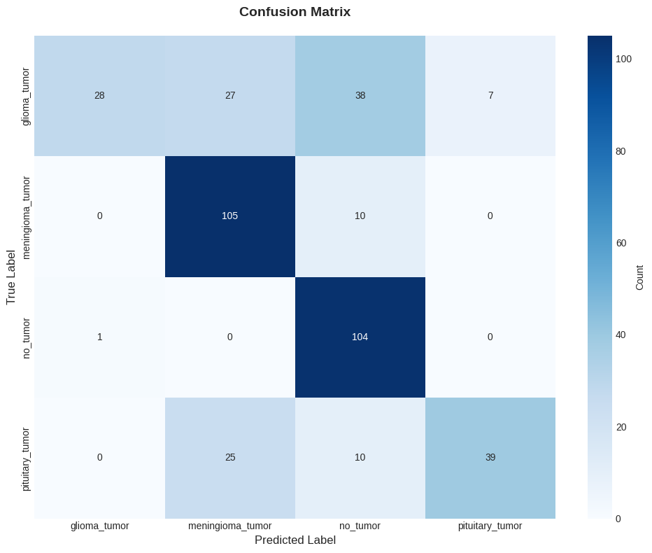

```
Normalized Confusion Matrix (percentages):
======================================================================
                  glioma_tumor  meningioma_tumor  no_tumor  pituitary_tumor
glioma_tumor             28.00             27.00     38.00              7.0
meningioma_tumor          0.00             91.30      8.70              0.0
no_tumor                  0.95              0.00     99.05              0.0
pituitary_tumor           0.00             33.78     13.51             52.7
```

```python
# Generate and plot confusion matrix
def plot_confusion_matrix(y_true, y_pred, class_names):
    """Plot confusion matrix."""
    cm = confusion_matrix(y_true, y_pred)

    # Calculate percentages
    cm_percent = cm.astype('float') / cm.sum(axis=1)[:, np.newaxis] * 100

    # Create figure
    fig, ax = plt.subplots(figsize=(10, 8))

    # Plot heatmap
    sns.heatmap(
        cm,
        annot=True,
        fmt='d',
        cmap='Blues',
        xticklabels=class_names,
        yticklabels=class_names,
        ax=ax,
        cbar_kws={'label': 'Count'}
    )

    ax.set_title('Confusion Matrix', fontsize=14, fontweight='bold', pad=20)
    ax.set_ylabel('True Label', fontsize=12)
    ax.set_xlabel('Predicted Label', fontsize=12)

    plt.tight_layout()
    plt.savefig(RESULTS_DIR / 'confusion_matrix.png', dpi=300, bbox_inches='tight')
    plt.show()

    # Print normalized confusion matrix
    print("\nNormalized Confusion Matrix (percentages):")
    print("="*70)
    cm_df = pd.DataFrame(cm_percent, index=class_names, columns=class_names)
    print(cm_df.round(2))

    return cm

cm = plot_confusion_matrix(y_true, y_pred, class_names_ordered)
```

### 6.5 Per-Class Metrics

```python
# Calculate per-class metrics
from sklearn.metrics import precision_recall_fscore_support

precision, recall, f1, support = precision_recall_fscore_support(
    y_true, y_pred, average=None, labels=range(NUM_CLASSES)
)

# Create DataFrame
metrics_df = pd.DataFrame({
    'Class': class_names_ordered,
    'Precision': precision,
    'Recall': recall,
    'F1-Score': f1,
    'Support': support
})

print("\nPer-Class Metrics:")
print("="*70)
print(metrics_df.to_string(index=False))

# Save to CSV
metrics_df.to_csv(RESULTS_DIR / 'per_class_metrics.csv', index=False)
print(f"\nMetrics saved to {RESULTS_DIR / 'per_class_metrics.csv'}")
```

```
Per-Class Metrics:
======================================================================
           Class  Precision   Recall  F1-Score  Support
    glioma_tumor   0.965517 0.280000  0.434109      100
meningioma_tumor   0.668790 0.913043  0.772059      115
        no_tumor   0.641975 0.990476  0.779026      105
 pituitary_tumor   0.847826 0.527027  0.650000       74

Metrics saved to results/per_class_metrics.csv
```

## 7. Results Visualization

### 7.1 Visualize Predictions

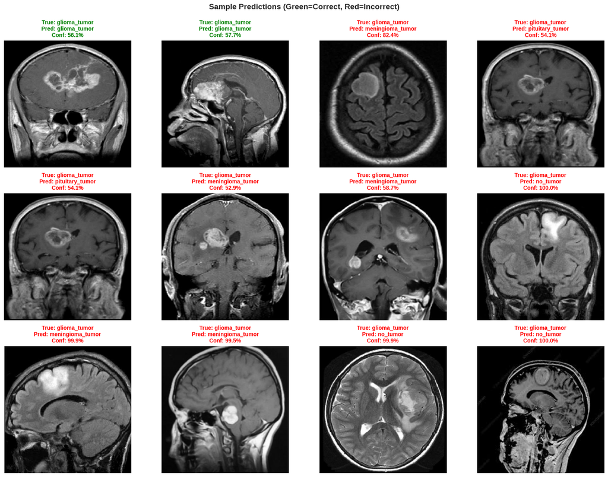

```python
# Visualize sample predictions
def visualize_predictions(generator, predictions, num_samples=12):
    """Display sample images with predictions."""
    generator.reset()

    # Get a batch of images
    images, labels = next(generator)
    pred_probs = predictions[:len(images)]

    # Select samples to display
    num_samples = min(num_samples, len(images))

    fig, axes = plt.subplots(3, 4, figsize=(16, 12))
    axes = axes.flatten()

    for i in range(num_samples):
        ax = axes[i]

        # Get true and predicted labels
        true_label_idx = np.argmax(labels[i])
        pred_label_idx = np.argmax(pred_probs[i])
        true_label = class_names_ordered[true_label_idx]
        pred_label = class_names_ordered[pred_label_idx]
        confidence = pred_probs[i][pred_label_idx] * 100

        # Display image
        ax.imshow(images[i])
        ax.axis('off')

        # Set title color based on correctness
        color = 'green' if true_label_idx == pred_label_idx else 'red'
        title = f"True: {true_label}\nPred: {pred_label}\nConf: {confidence:.1f}%"
        ax.set_title(title, fontsize=10, color=color, fontweight='bold')

    plt.suptitle('Sample Predictions (Green=Correct, Red=Incorrect)',
                 fontsize=14, fontweight='bold', y=0.995)
    plt.tight_layout()
    plt.savefig(RESULTS_DIR / 'sample_predictions.png', dpi=300, bbox_inches='tight')
    plt.show()

visualize_predictions(test_generator, y_pred_probs, num_samples=12)
```

### 7.2 ROC Curves

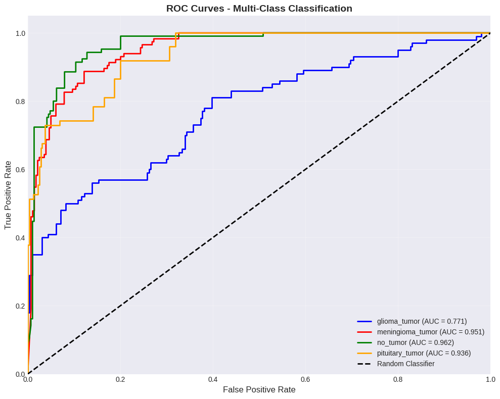

```
AUC Scores per Class:
========================================
glioma_tumor        : 0.7705
meningioma_tumor    : 0.9508
no_tumor            : 0.9625
pituitary_tumor     : 0.9361
Mean AUC            : 0.9050
```

```python
# Plot ROC curves for each class
def plot_roc_curves(y_true, y_pred_probs, class_names):
    """Plot ROC curves for multi-class classification."""
    # Binarize labels for ROC curve
    y_true_bin = label_binarize(y_true, classes=range(len(class_names)))

    # Calculate ROC curve and AUC for each class
    fpr = dict()
    tpr = dict()
    roc_auc = dict()

    for i in range(len(class_names)):
        fpr[i], tpr[i], _ = roc_curve(y_true_bin[:, i], y_pred_probs[:, i])
        roc_auc[i] = auc(fpr[i], tpr[i])

    # Plot ROC curves
    plt.figure(figsize=(10, 8))
    colors = ['blue', 'red', 'green', 'orange']

    for i, color in zip(range(len(class_names)), colors):
        plt.plot(
            fpr[i], tpr[i],
            color=color,
            linewidth=2,
            label=f'{class_names[i]} (AUC = {roc_auc[i]:.3f})'
        )

    plt.plot([0, 1], [0, 1], 'k--', linewidth=2, label='Random Classifier')
    plt.xlim([0.0, 1.0])
    plt.ylim([0.0, 1.05])
    plt.xlabel('False Positive Rate', fontsize=12)
    plt.ylabel('True Positive Rate', fontsize=12)
    plt.title('ROC Curves - Multi-Class Classification', fontsize=14, fontweight='bold')
    plt.legend(loc='lower right', fontsize=10)
    plt.grid(True, alpha=0.3)
    plt.tight_layout()
    plt.savefig(RESULTS_DIR / 'roc_curves.png', dpi=300, bbox_inches='tight')
    plt.show()

    # Print AUC scores
    print("\nAUC Scores per Class:")
    print("="*40)
    for i, class_name in enumerate(class_names):
        print(f"{class_name:20s}: {roc_auc[i]:.4f}")
    print(f"{'Mean AUC':20s}: {np.mean(list(roc_auc.values())):.4f}")

plot_roc_curves(y_true, y_pred_probs, class_names_ordered)
```

### 7.3 Error Analysis

```python
# Analyze misclassified samples
def analyze_errors(y_true, y_pred, class_names):
    """Analyze misclassification patterns."""
    # Find misclassified indices
    misclassified_idx = np.where(y_true != y_pred)[0]

    print(f"\nError Analysis:")
    print("="*70)
    print(f"Total test samples: {len(y_true)}")
    print(f"Correctly classified: {len(y_true) - len(misclassified_idx)}")
    print(f"Misclassified: {len(misclassified_idx)}")
    print(f"Error rate: {len(misclassified_idx) / len(y_true) * 100:.2f}%")

    # Most common misclassifications
    print("\nMost Common Misclassifications:")
    print("="*70)

    error_pairs = []
    for idx in misclassified_idx:
        true_class = class_names[y_true[idx]]
        pred_class = class_names[y_pred[idx]]
        error_pairs.append((true_class, pred_class))

    from collections import Counter
    error_counts = Counter(error_pairs)

    for (true_class, pred_class), count in error_counts.most_common(5):
        print(f"{true_class:20s} -> {pred_class:20s}: {count} times")

analyze_errors(y_true, y_pred, class_names_ordered)
```

```
Error Analysis:
======================================================================
Total test samples: 394
Correctly classified: 276
Misclassified: 118
Error rate: 29.95%

Most Common Misclassifications:
======================================================================
glioma_tumor         -> no_tumor            : 38 times
glioma_tumor         -> meningioma_tumor    : 27 times
pituitary_tumor      -> meningioma_tumor    : 25 times
meningioma_tumor     -> no_tumor            : 10 times
pituitary_tumor      -> no_tumor            : 10 times
```

## 8. Conclusions

### 8.1 Summary of Results

```python
# Create comprehensive results summary
summary = f"""
{'='*70}
BRAIN TUMOR CLASSIFICATION - FINAL RESULTS SUMMARY
{'='*70}

MODEL ARCHITECTURE:
  Base Model: VGG16 (pre-trained on ImageNet)
  Transfer Learning: Fine-tuning all layers
  Total Parameters: {total_params:,}
  Trainable Parameters: {trainable_params:,}

DATASET:
  Total Images: {df_stats['Total'].sum()}
  Training Samples: {train_generator.samples}
  Validation Samples: {val_generator.samples}
  Test Samples: {test_generator.samples}
  Number of Classes: {NUM_CLASSES}

TRAINING CONFIGURATION:
  Optimizer: Adam
  Initial Learning Rate: 0.0001
  Batch Size: {BATCH_SIZE}
  Epochs Trained: {len(history.history['loss'])}
  Data Augmentation: Yes

PERFORMANCE METRICS:
  Test Accuracy: {test_accuracy:.4f} ({test_accuracy*100:.2f}%)
  Test Loss: {test_loss:.4f}
  Mean F1-Score: {metrics_df['F1-Score'].mean():.4f}
  Mean Precision: {metrics_df['Precision'].mean():.4f}
  Mean Recall: {metrics_df['Recall'].mean():.4f}

PER-CLASS PERFORMANCE:
"""

for idx, row in metrics_df.iterrows():
    summary += f"  {row['Class']:20s}: F1={row['F1-Score']:.4f}, Precision={row['Precision']:.4f}, Recall={row['Recall']:.4f}\n"

summary += f"""
{'='*70}
"""

print(summary)

# Save summary
with open(RESULTS_DIR / 'results_summary.txt', 'w') as f:
    f.write(summary)

print(f"\nResults summary saved to {RESULTS_DIR / 'results_summary.txt'}")
```

```
======================================================================
BRAIN TUMOR CLASSIFICATION - FINAL RESULTS SUMMARY
======================================================================

MODEL ARCHITECTURE:
  Base Model: VGG16 (pre-trained on ImageNet)
  Transfer Learning: Fine-tuning all layers
  Total Parameters: 14,815,044
  Trainable Parameters: 14,815,044

DATASET:
  Total Images: 3264
  Training Samples: 2297
  Validation Samples: 573
  Test Samples: 394
  Number of Classes: 4

TRAINING CONFIGURATION:
  Optimizer: Adam
  Initial Learning Rate: 0.0001
  Batch Size: 32
  Epochs Trained: 27
  Data Augmentation: Yes

PERFORMANCE METRICS:
  Test Accuracy: 0.7005 (70.05%)
  Test Loss: 2.5700
  Mean F1-Score: 0.6588
  Mean Precision: 0.7810
  Mean Recall: 0.6776

PER-CLASS PERFORMANCE:
  glioma_tumor        : F1=0.4341, Precision=0.9655, Recall=0.2800
  meningioma_tumor    : F1=0.7721, Precision=0.6688, Recall=0.9130
  no_tumor            : F1=0.7790, Precision=0.6420, Recall=0.9905
  pituitary_tumor     : F1=0.6500, Precision=0.8478, Recall=0.5270

======================================================================


Results summary saved to results/results_summary.txt
```

### 8.3 Future Improvements

1. **Ensemble Methods**: Combine predictions from multiple architectures (VGG16, ResNet, Inception)
2. **Advanced Architectures**: Experiment with newer architectures like EfficientNet or Vision Transformers
3. **Grad-CAM Visualization**: Add gradient-based visualization to understand model decision-making
4. **Cross-Validation**: Implement k-fold cross-validation for more robust performance estimation
5. **External Validation**: Test on external datasets to assess generalization
6. **Class Imbalance**: Address class imbalance with techniques like class weights or SMOTE

### 8.4 Save Final Model

```python
# Save final model
final_model_path = MODEL_DIR / 'final_model.h5'
model.save(final_model_path)
print(f"Final model saved to: {final_model_path}")

# Save model architecture as JSON
model_json = model.to_json()
with open(MODEL_DIR / 'model_architecture.json', 'w') as json_file:
    json_file.write(model_json)
print(f"Model architecture saved to: {MODEL_DIR / 'model_architecture.json'}")

print("\nAll results and models have been saved successfully!")
```

```
WARNING:absl:You are saving your model as an HDF5 file via `model.save()` or `keras.saving.save_model(model)`. This file format is considered legacy. We recommend using instead the native Keras format, e.g. `model.save('my_model.keras')` or `keras.saving.save_model(model, 'my_model.keras')`.
```

```
Final model saved to: models/final_model.h5
Model architecture saved to: models/model_architecture.json

All results and models have been saved successfully!
```

## References

1. **Dataset**:
   - Bhuvaji, S., Kadam, A., Bhumkar, P., Dedge, S., & Kanchan, S. (2020). Brain tumor classification (MRI). Kaggle, 10.
2. **Baseline Implementation**:
   - Kadam, A., Bhuvaji, S., & Deshpande, S. (2021). Brain tumor classification using deep learning algorithms. Int. J. Res. Appl. Sci. Eng. Technol, 9, 417-426.
3. **VGG16 Architecture**:
   - Simonyan, K., & Zisserman, A. (2014). Very deep convolutional networks for large-scale image recognition. arXiv preprint arXiv:1409.1556.
4. **Transfer Learning**:
   - Yosinski, J., Clune, J., Bengio, Y., & Lipson, H. (2014). How transferable are features in deep neural networks?. Advances in neural information processing systems, 27.

**End of Notebook**